# SQ trig

#### Solution

#### Question

29. A right triangle has an angle measure $\theta$. The opposite leg’s length is 86 meters, and the hypotenuse’s length is 96 meters. What is the angle measure $\theta$ in degrees?

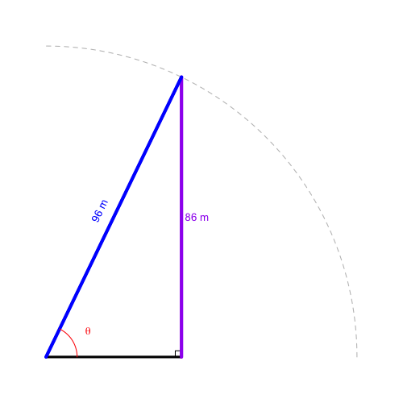

    Please round your answer to the tenth of a degree.

#### Solution

#### Question

30. A right triangle has an angle measure $\theta$. The opposite leg’s length is 31 meters, and the hypotenuse’s length is 69 meters. What is the angle measure $\theta$ in degrees?

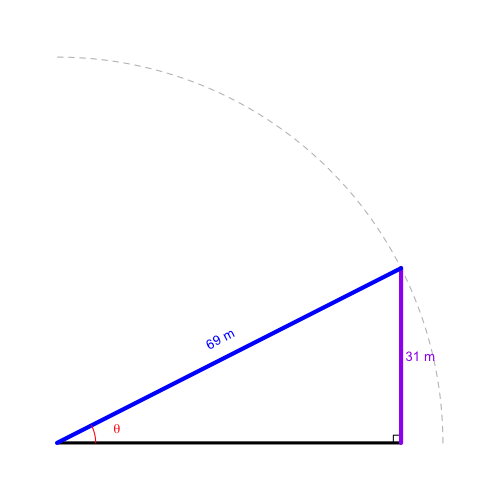

    Please round your answer to the tenth of a degree.

#### Solution

#### Question

31. A right triangle has an angle of 44.7 degrees. The hypotenuse has a length of 71 meters. How long, in meters, is the leg adjacent the angle?

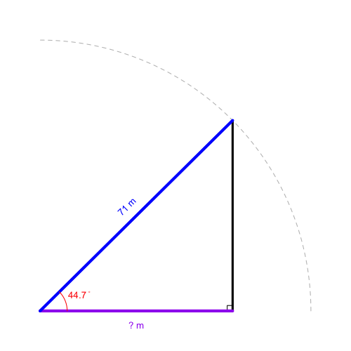

    Please round your answer to the nearest meter.

#### Solution

#### Question

32. A right triangle has an angle of 29.2 degrees. The hypotenuse has a length of 54 meters. How long, in meters, is the leg adjacent the angle?

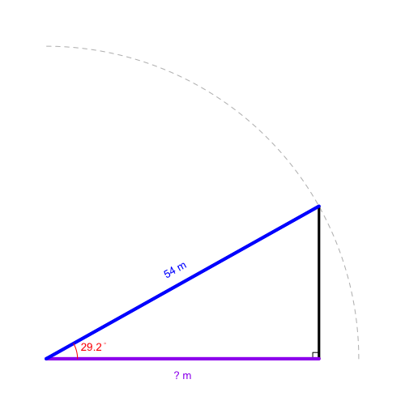

    Please round your answer to the nearest meter.

#### Solution

#### Question

33. A right triangle has an angle of 32.7 degrees. The hypotenuse has a length of 83 meters. How long, in meters, is the leg adjacent the angle?

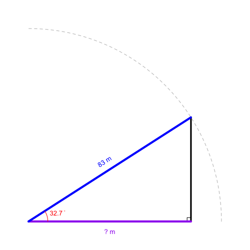

    Please round your answer to the nearest meter.

#### Solution

#### Question

34. A right triangle has an angle of 27.5 degrees. The hypotenuse has a length of 95 meters. How long, in meters, is the leg adjacent the angle?

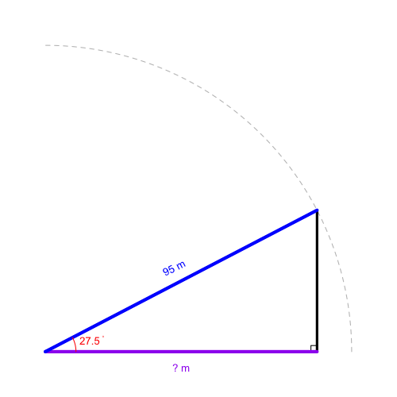

    Please round your answer to the nearest meter.

#### Solution

#### Question

35. A right triangle has an angle of 58.4 degrees. The hypotenuse has a length of 41 meters. How long, in meters, is the leg adjacent the angle?

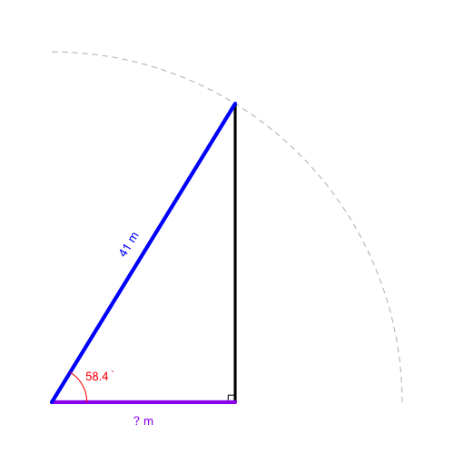

    Please round your answer to the nearest meter.

#### Solution

#### Question

36. A right triangle has an angle of 56.7 degrees. The hypotenuse has a length of 96 meters. How long, in meters, is the leg adjacent the angle?

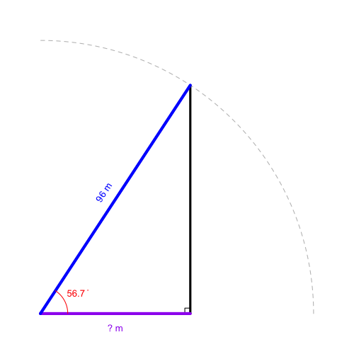

    Please round your answer to the nearest meter.

#### Solution

#### Question

37. A right triangle has an angle of 42.4 degrees. The hypotenuse has a length of 54 meters. How long, in meters, is the leg adjacent the angle?

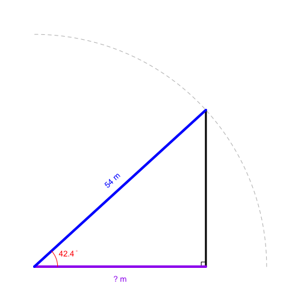

    Please round your answer to the nearest meter.

#### Solution

#### Question

38. A right triangle has an angle of 41.3 degrees. The hypotenuse has a length of 56 meters. How long, in meters, is the leg adjacent the angle?

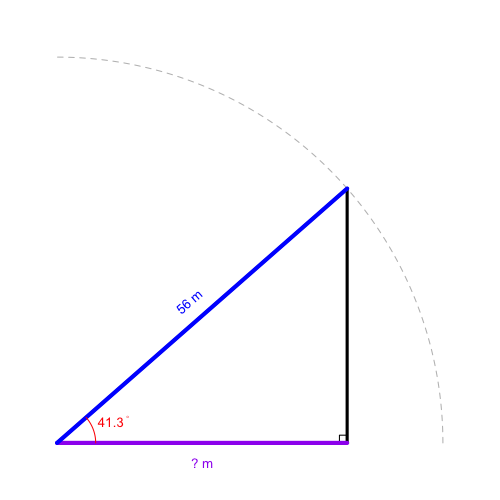

    Please round your answer to the nearest meter.

#### Solution

#### Question

39. A right triangle has an angle of 53.3 degrees. The hypotenuse has a length of 27 meters. How long, in meters, is the leg adjacent the angle?

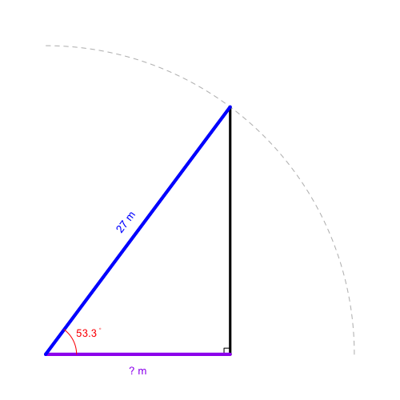

    Please round your answer to the nearest meter.

#### Solution

#### Question

40. A right triangle has an angle of 64.2 degrees. The hypotenuse has a length of 26 meters. How long, in meters, is the leg adjacent the angle?

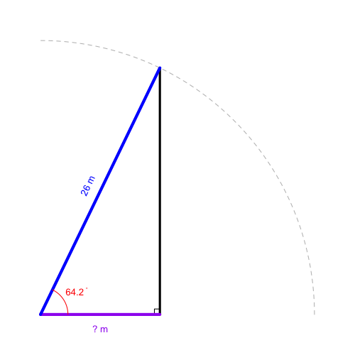

    Please round your answer to the nearest meter.

#### Solution

#### Question

41. A right triangle has an angle of 30.9 degrees. The adjacent leg has a length of 58 meters. How long, in meters, is the hypotenuse?

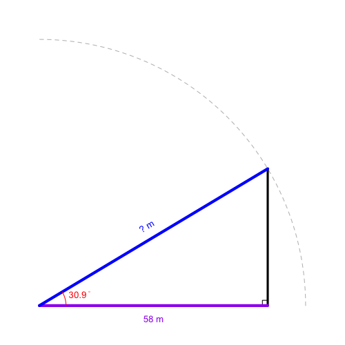

    Please round your answer to the nearest meter.

#### Solution

#### Question

42. A right triangle has an angle of 57.9 degrees. The adjacent leg has a length of 12 meters. How long, in meters, is the hypotenuse?

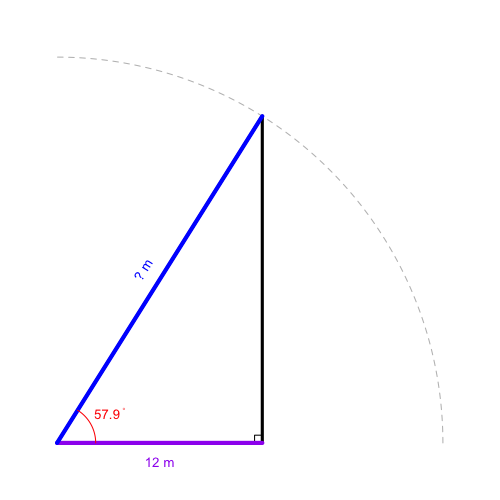

    Please round your answer to the nearest meter.

#### Solution

#### Question

43. A right triangle has an angle of 32.1 degrees. The adjacent leg has a length of 76 meters. How long, in meters, is the hypotenuse?

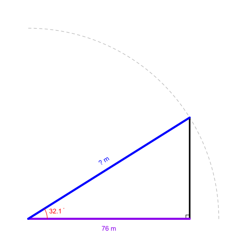

    Please round your answer to the nearest meter.

#### Solution

#### Question

44. A right triangle has an angle of 29.2 degrees. The adjacent leg has a length of 14 meters. How long, in meters, is the hypotenuse?

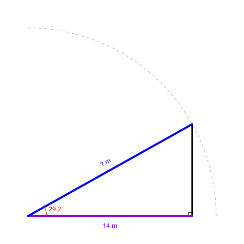

    Please round your answer to the nearest meter.

#### Solution

#### Question

45. A right triangle has an angle of 37.8 degrees. The adjacent leg has a length of 17 meters. How long, in meters, is the hypotenuse?

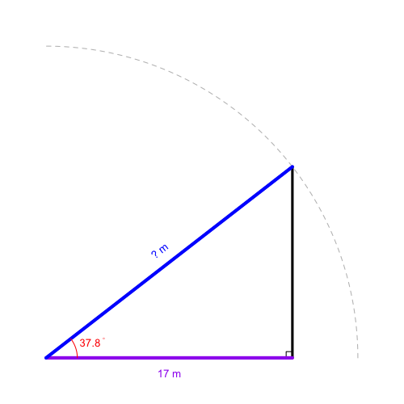

    Please round your answer to the nearest meter.

#### Solution

#### Question

46. A right triangle has an angle of 43.0 degrees. The adjacent leg has a length of 26 meters. How long, in meters, is the hypotenuse?

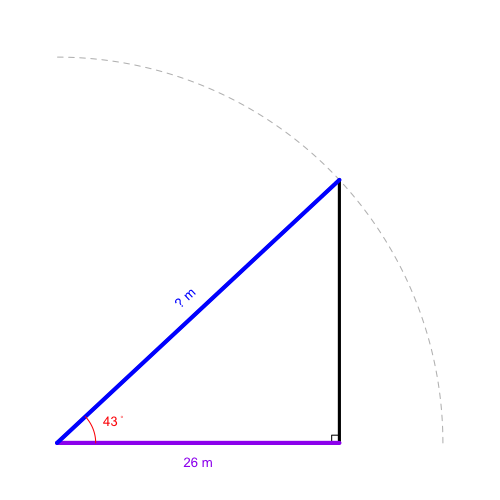

    Please round your answer to the nearest meter.

#### Solution

#### Question

47. A right triangle has an angle of 64.2 degrees. The adjacent leg has a length of 13 meters. How long, in meters, is the hypotenuse?

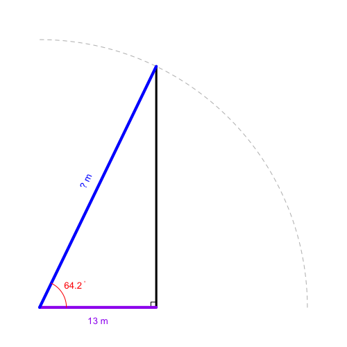

    Please round your answer to the nearest meter.

#### Solution

#### Question

48. A right triangle has an angle of 40.1 degrees. The adjacent leg has a length of 51 meters. How long, in meters, is the hypotenuse?

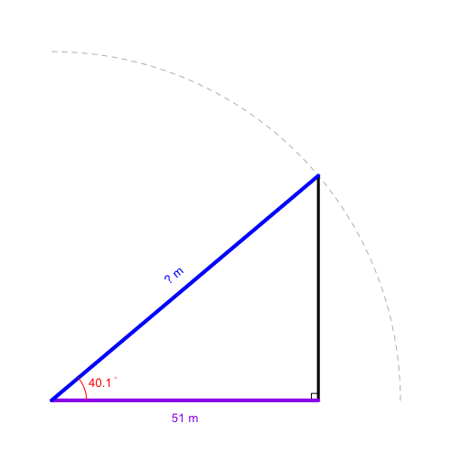

    Please round your answer to the nearest meter.

#### Solution

#### Question

49. A right triangle has an angle of 39.0 degrees. The adjacent leg has a length of 30 meters. How long, in meters, is the hypotenuse?

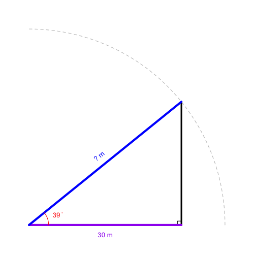

    Please round your answer to the nearest meter.

#### Solution

#### Question

50. A right triangle has an angle of 49.3 degrees. The adjacent leg has a length of 46 meters. How long, in meters, is the hypotenuse?

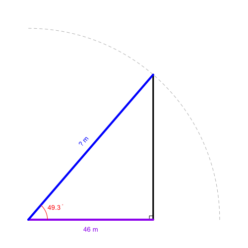

    Please round your answer to the nearest meter.

#### Solution

#### Question

51. A right triangle has an angle measure $\theta$. The adjacent leg’s length is 12 meters, and the hypotenuse’s length is 32 meters. What is the angle measure $\theta$ in degrees?

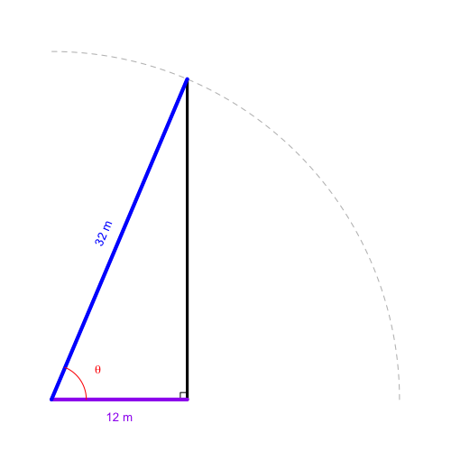

    Please round your answer to the nearest tenth of a degree.

#### Solution

#### Question

52. A right triangle has an angle measure $\theta$. The adjacent leg’s length is 25 meters, and the hypotenuse’s length is 28 meters. What is the angle measure $\theta$ in degrees?

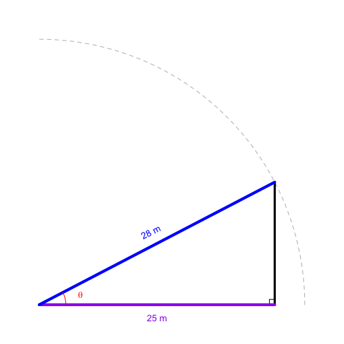

    Please round your answer to the nearest tenth of a degree.

#### Solution

#### Question

53. A right triangle has an angle measure $\theta$. The adjacent leg’s length is 35 meters, and the hypotenuse’s length is 47 meters. What is the angle measure $\theta$ in degrees?

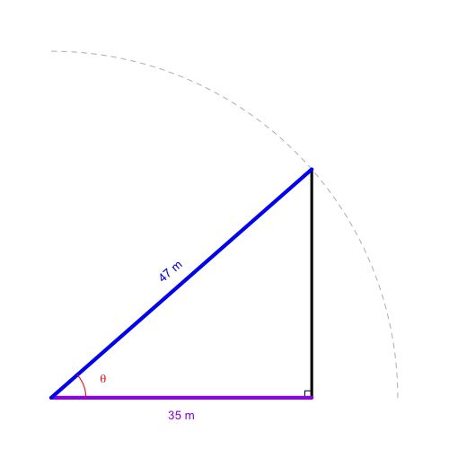

    Please round your answer to the nearest tenth of a degree.

#### Solution

#### Question

54. A right triangle has an angle measure $\theta$. The adjacent leg’s length is 63 meters, and the hypotenuse’s length is 82 meters. What is the angle measure $\theta$ in degrees?

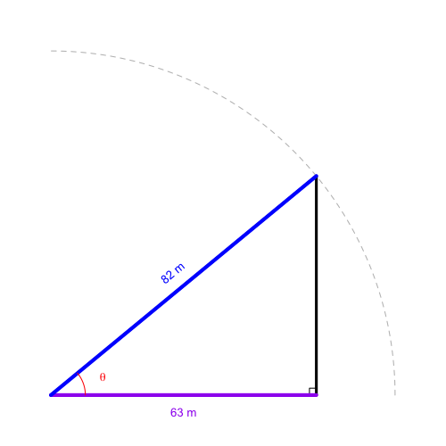

    Please round your answer to the nearest tenth of a degree.

#### Solution

#### Question

55. A right triangle has an angle measure $\theta$. The adjacent leg’s length is 27 meters, and the hypotenuse’s length is 81 meters. What is the angle measure $\theta$ in degrees?

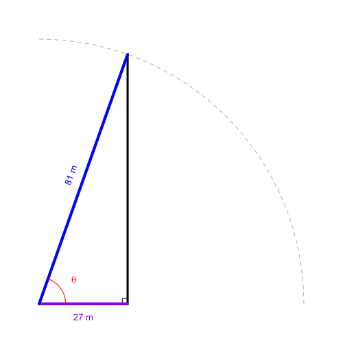

    Please round your answer to the nearest tenth of a degree.

#### Solution

#### Question

56. A right triangle has an angle measure $\theta$. The adjacent leg’s length is 32 meters, and the hypotenuse’s length is 49 meters. What is the angle measure $\theta$ in degrees?

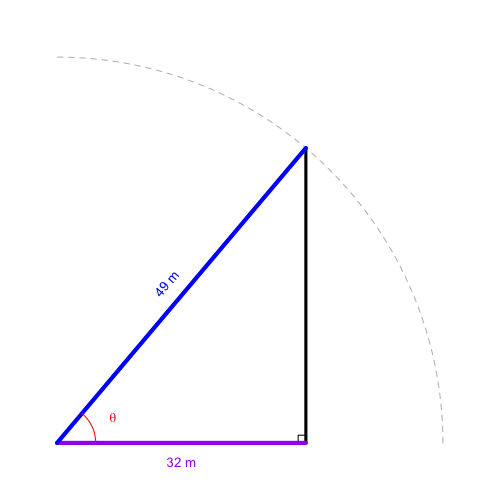

    Please round your answer to the nearest tenth of a degree.

#### Solution

#### Question

57. A right triangle has an angle measure $\theta$. The adjacent leg’s length is 21 meters, and the hypotenuse’s length is 27 meters. What is the angle measure $\theta$ in degrees?

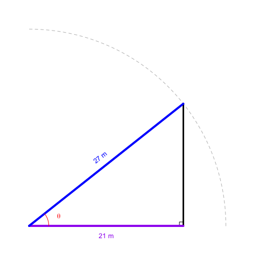

    Please round your answer to the nearest tenth of a degree.

#### Solution

#### Question

58. A right triangle has an angle measure $\theta$. The adjacent leg’s length is 19 meters, and the hypotenuse’s length is 39 meters. What is the angle measure $\theta$ in degrees?

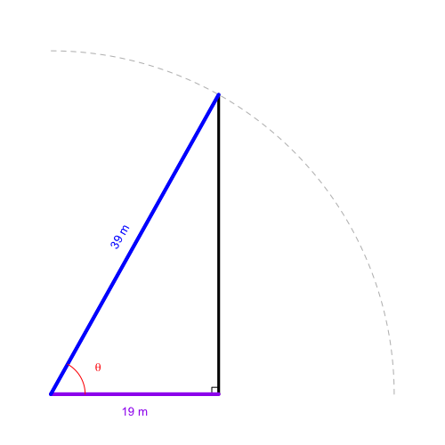

    Please round your answer to the nearest tenth of a degree.

#### Solution

#### Question

59. A right triangle has an angle measure $\theta$. The adjacent leg’s length is 36 meters, and the hypotenuse’s length is 51 meters. What is the angle measure $\theta$ in degrees?

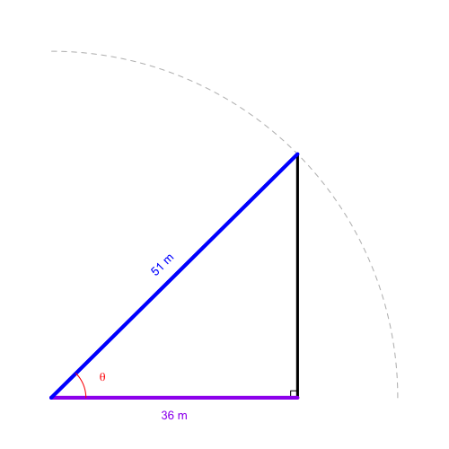

    Please round your answer to the nearest tenth of a degree.

#### Solution

#### Question

60. A right triangle has an angle measure $\theta$. The adjacent leg’s length is 71 meters, and the hypotenuse’s length is 94 meters. What is the angle measure $\theta$ in degrees?

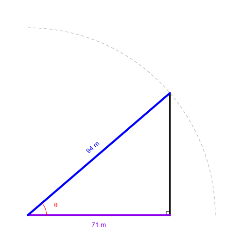

    Please round your answer to the nearest tenth of a degree.

#### Solution

#### Question

61. A right triangle has an angle of 58.4 degrees. The adjacent leg has a length of 35 meters. How long, in meters, is the leg opposite the angle?

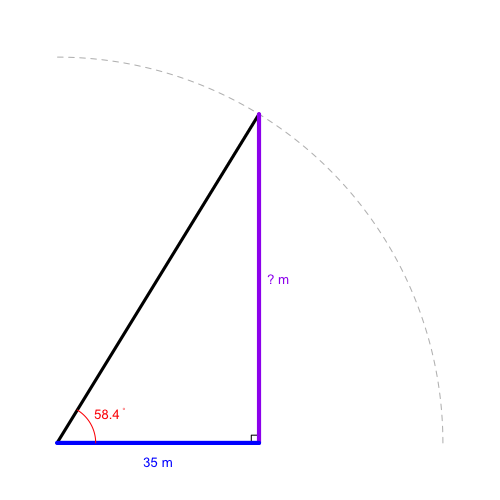

    Please round your answer to the nearest meter.

#### Solution

#### Question

62. A right triangle has an angle of 72.2 degrees. The adjacent leg has a length of 21 meters. How long, in meters, is the leg opposite the angle?

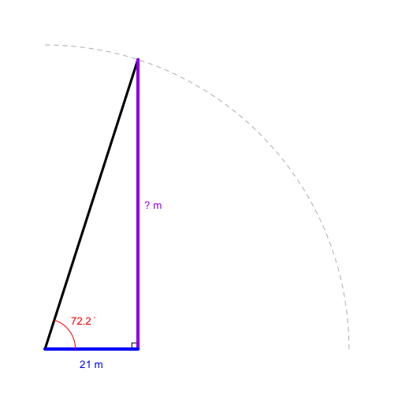

    Please round your answer to the nearest meter.

#### Solution

#### Question

63. A right triangle has an angle of 47.6 degrees. The adjacent leg has a length of 37 meters. How long, in meters, is the leg opposite the angle?

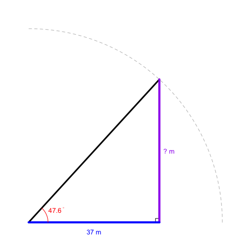

    Please round your answer to the nearest meter.

#### Solution

#### Question

64. A right triangle has an angle of 53.3 degrees. The adjacent leg has a length of 30 meters. How long, in meters, is the leg opposite the angle?

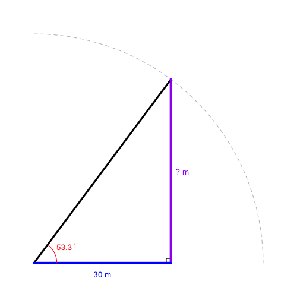

    Please round your answer to the nearest meter.

#### Solution

#### Question

65. A right triangle has an angle of 67.0 degrees. The adjacent leg has a length of 31 meters. How long, in meters, is the leg opposite the angle?

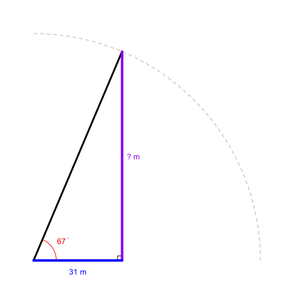

    Please round your answer to the nearest meter.

#### Solution

#### Question

66. A right triangle has an angle of 51.6 degrees. The adjacent leg has a length of 11 meters. How long, in meters, is the leg opposite the angle?

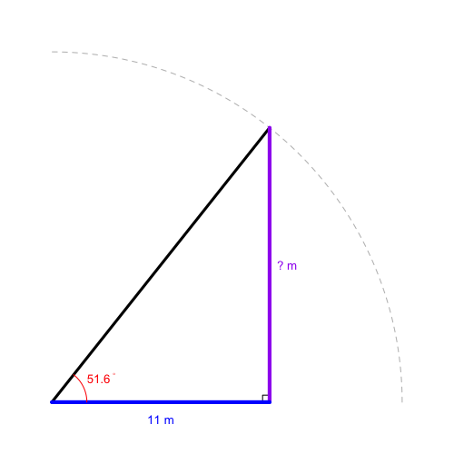

    Please round your answer to the nearest meter.

#### Solution

#### Question

67. A right triangle has an angle of 55.0 degrees. The adjacent leg has a length of 47 meters. How long, in meters, is the leg opposite the angle?

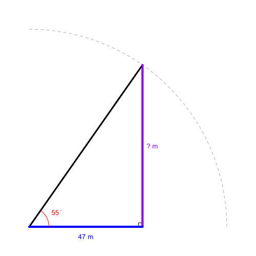

    Please round your answer to the nearest meter.

#### Solution

#### Question

68. A right triangle has an angle of 59.6 degrees. The adjacent leg has a length of 33 meters. How long, in meters, is the leg opposite the angle?

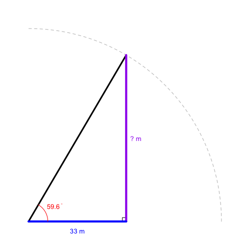

    Please round your answer to the nearest meter.

#### Solution

#### Question

69. A right triangle has an angle of 44.7 degrees. The adjacent leg has a length of 68 meters. How long, in meters, is the leg opposite the angle?

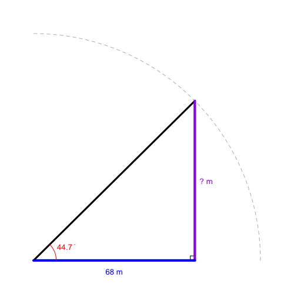

    Please round your answer to the nearest meter.

#### Solution

#### Question

70. A right triangle has an angle of 47.0 degrees. The adjacent leg has a length of 29 meters. How long, in meters, is the leg opposite the angle?

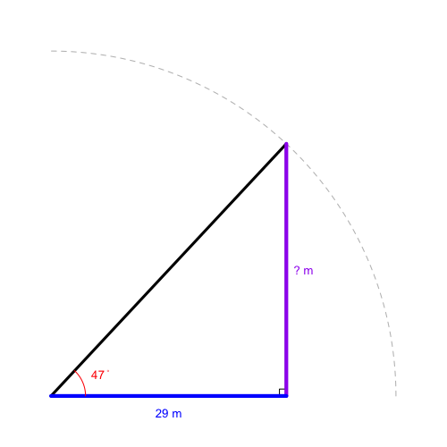

    Please round your answer to the nearest meter.

#### Solution

#### Question

71. A right triangle has an angle of 46.4 degrees. The opposite leg has a length of 58 meters. How long, in meters, is the leg adjacent the angle?

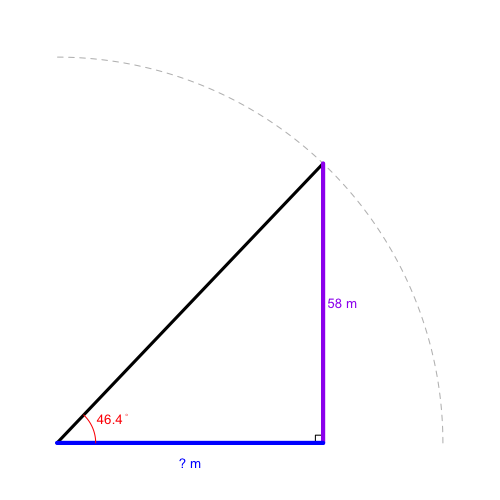

    Please round your answer to the nearest meter.

#### Solution

#### Question

72. A right triangle has an angle of 37.2 degrees. The opposite leg has a length of 14 meters. How long, in meters, is the leg adjacent the angle?

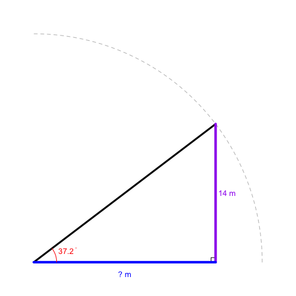

    Please round your answer to the nearest meter.

#### Solution

#### Question

73. A right triangle has an angle of 69.3 degrees. The opposite leg has a length of 82 meters. How long, in meters, is the leg adjacent the angle?

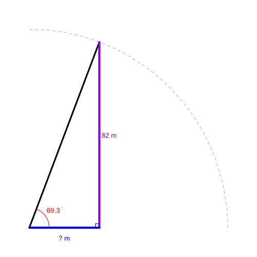

    Please round your answer to the nearest meter.

#### Solution

#### Question

74. A right triangle has an angle of 61.9 degrees. The opposite leg has a length of 26 meters. How long, in meters, is the leg adjacent the angle?

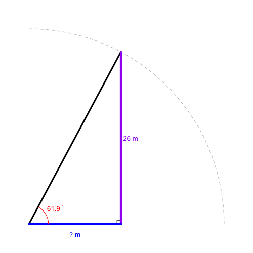

    Please round your answer to the nearest meter.

#### Solution

#### Question

75. A right triangle has an angle of 44.1 degrees. The opposite leg has a length of 50 meters. How long, in meters, is the leg adjacent the angle?

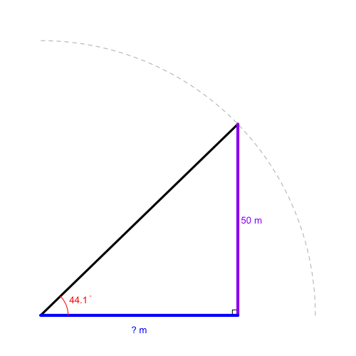

    Please round your answer to the nearest meter.

#### Solution

#### Question

76. A right triangle has an angle of 42.4 degrees. The opposite leg has a length of 41 meters. How long, in meters, is the leg adjacent the angle?

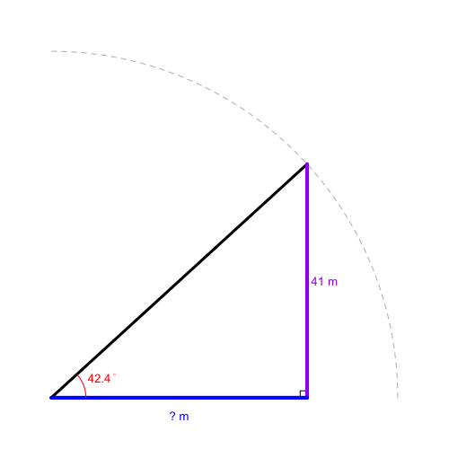

    Please round your answer to the nearest meter.

#### Solution

#### Question

77. A right triangle has an angle of 52.7 degrees. The opposite leg has a length of 25 meters. How long, in meters, is the leg adjacent the angle?

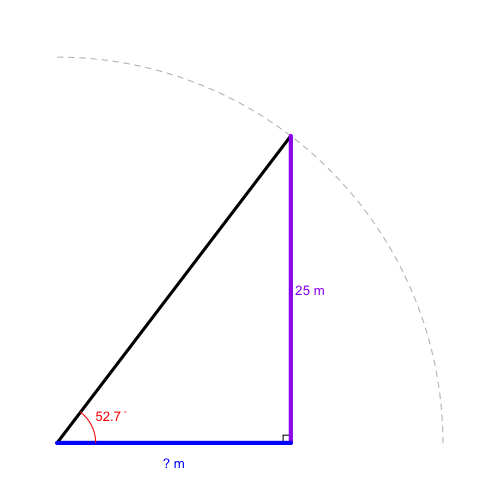

    Please round your answer to the nearest meter.

#### Solution

#### Question

78. A right triangle has an angle of 29.2 degrees. The opposite leg has a length of 27 meters. How long, in meters, is the leg adjacent the angle?

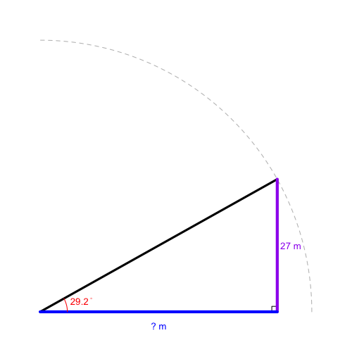

    Please round your answer to the nearest meter.

#### Solution

#### Question

79. A right triangle has an angle of 59.0 degrees. The opposite leg has a length of 58 meters. How long, in meters, is the leg adjacent the angle?

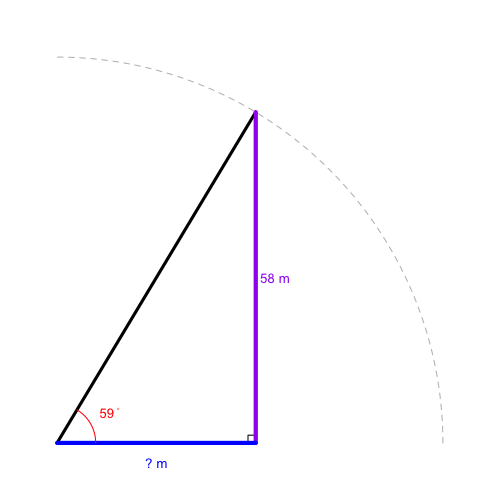

    Please round your answer to the nearest meter.

#### Solution

#### Question

80. A right triangle has an angle of 50.4 degrees. The opposite leg has a length of 52 meters. How long, in meters, is the leg adjacent the angle?

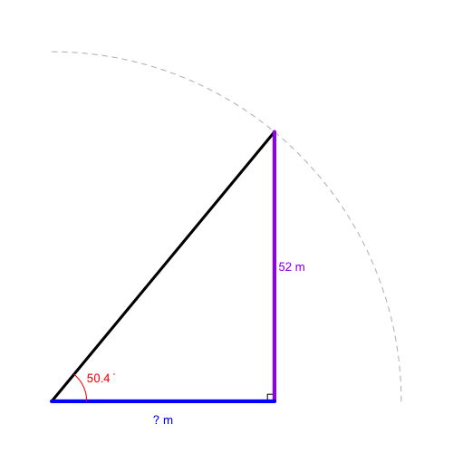

    Please round your answer to the nearest meter.

#### Solution

#### Question

81. A right triangle has an angle of $\theta$ radians. The adjacent leg has a length of 34 meters, and the opposite leg has a length of 54 meters. What is the angle measure $\theta$ in radians?

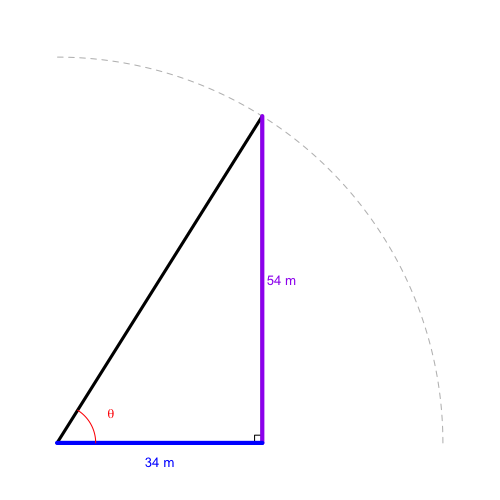

    Please round your answer to the nearest tenth of a degree.

#### Solution

#### Question

82. A right triangle has an angle of $\theta$ radians. The adjacent leg has a length of 38 meters, and the opposite leg has a length of 79 meters. What is the angle measure $\theta$ in radians?

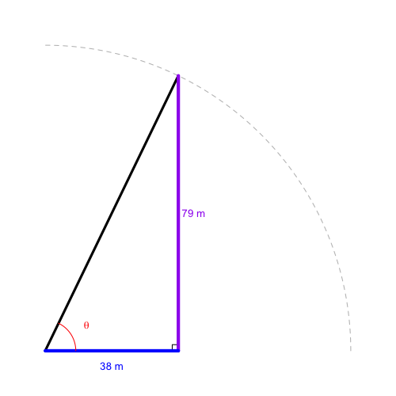

    Please round your answer to the nearest tenth of a degree.

#### Solution

#### Question

83. A right triangle has an angle of $\theta$ radians. The adjacent leg has a length of 28 meters, and the opposite leg has a length of 46 meters. What is the angle measure $\theta$ in radians?

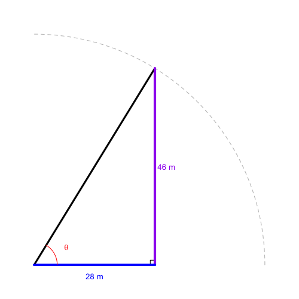

    Please round your answer to the nearest tenth of a degree.

#### Solution

#### Question

84. A right triangle has an angle of $\theta$ radians. The adjacent leg has a length of 40 meters, and the opposite leg has a length of 89 meters. What is the angle measure $\theta$ in radians?

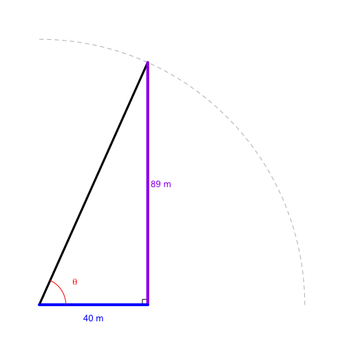

    Please round your answer to the nearest tenth of a degree.

#### Solution

#### Question

85. A right triangle has an angle of $\theta$ radians. The adjacent leg has a length of 32 meters, and the opposite leg has a length of 80 meters. What is the angle measure $\theta$ in radians?

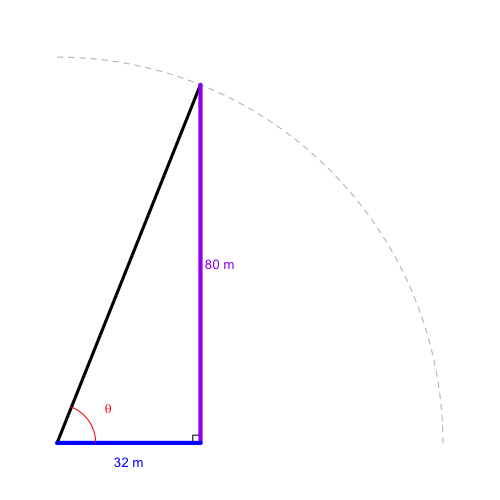

    Please round your answer to the nearest tenth of a degree.

#### Solution

#### Question

86. A right triangle has an angle of $\theta$ radians. The adjacent leg has a length of 25 meters, and the opposite leg has a length of 28 meters. What is the angle measure $\theta$ in radians?

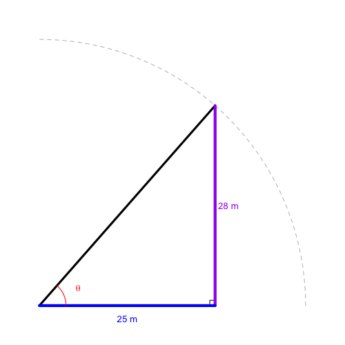

    Please round your answer to the nearest tenth of a degree.

#### Solution

#### Question

87. A right triangle has an angle of $\theta$ radians. The adjacent leg has a length of 67 meters, and the opposite leg has a length of 64 meters. What is the angle measure $\theta$ in radians?

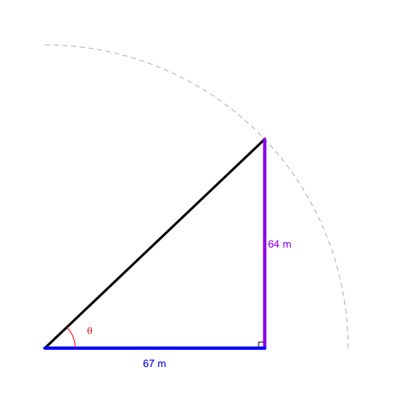

    Please round your answer to the nearest tenth of a degree.

#### Solution

#### Question

88. A right triangle has an angle of $\theta$ radians. The adjacent leg has a length of 23 meters, and the opposite leg has a length of 74 meters. What is the angle measure $\theta$ in radians?

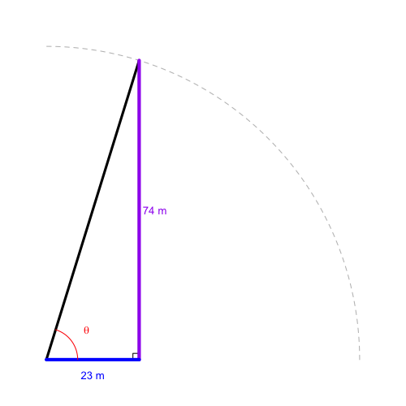

    Please round your answer to the nearest tenth of a degree.

#### Solution

#### Question

89. A right triangle has an angle of $\theta$ radians. The adjacent leg has a length of 38 meters, and the opposite leg has a length of 53 meters. What is the angle measure $\theta$ in radians?

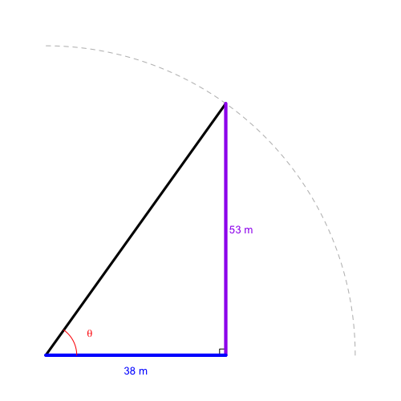

    Please round your answer to the nearest tenth of a degree.

#### Solution

#### Question

90. A right triangle has an angle of $\theta$ radians. The adjacent leg has a length of 62 meters, and the opposite leg has a length of 43 meters. What is the angle measure $\theta$ in radians?

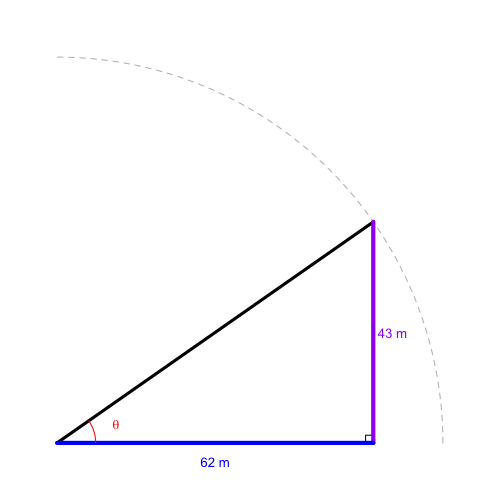

    Please round your answer to the nearest tenth of a degree.

#### Solution